# Raport końcowy - Analiza spółki Dino

### Spis treści

1. Dane spółki, charakterystyka, notowania
2. Wstępna analiza bilansu
3. Wstępna analiza rachunku zysków i strat
4. Analiza przepływów środków pieniężnych Dino oraz porównanie ze spółką konkurencyjną Biedronka
5. Analiza wskaźnikowa
6. Podsumowanie Analizy spółki Dino

   Załącznik

## 1 Dane spółki, charakterystyka, notowania

Spółka [Dino](https://grupadino.pl) to Polska sieć handlu spożywczego założona w 1999 roku przez Tomasza Biernackiego. Jest to wiodący gracz w rosnącym segmencie średniej wielkości supermarketów w Polsce, zlokalizowanych głównie w mniejszych miejscowościach, małych i średnich miastach oraz na peryferiach dużych miast. W latach 2010-2019 liczba sklepów wzrosła ze 111 na koniec 2010 do 1218 na koniec 2019 roku.

- **Zarząd Spółki**: Szymon Piduch – Prezes Zarządu, Michał Krauze – Członek Zarządu, Dyrektor Finansowy, Michał Muskała – Członek Zarządu, Dyrektor Inwestycji
- **Rada Nadzorcza**: Tomasz Biernacki - przewodniczący rady nadzorczej, Eryk Bajer - członek rady nadzorczej, Sławomir Jakszuk - niezależny członek rady nadzorczej, Piotr Nowjalis - niezależny członek rady nadzorczej, Maciej Polanowski - członek rady nadzorczej
- **Siedziba Spółki**: ul. Ostrowska 122, 63-700 Krotoszyn, Polska
- **Komitet audytu**: Piotr Nowjalis – przewodniczący komitetu audytu, Sławomir Jakszuk – członek komitetu audytu, Maciej Polanowski – członek komitetu audytu

### 1.1 Historia rozwoju

Grupa Dino jest jedną z najszybciej rozwijających się sieci supermarketów *proximity* w Polsce – zarówno pod względem liczby sklepów, jak i przychodów ze sprzedaży.

Poniżej przedstawiamy wydarzenia, które odegrały ważną rolę w jej historii.

- 1999 : Pierwsze sklep pod marką Dino
- 2002 : Pierwsze centrum dystrybucyjne
- 2003 : Dino zacieśnia relacje z zakadami mięsnymi Agro-Rydzyna
- 2004-2009 : Rozwój wokół centrum dystrybucyjnego
- 2010 : 100 Sklepów i okres dynamicznej ekspansji
- 2013 : 300 sklepów i drugie centrum Dystrybucyjne
- 2014 - 2015 : 500 sklepów
- 2016 : 10,000 pracaowników i trzecie centrum Dystrybucyjne
- 2017 : Debiut na GPW
- 2018 : 202 otwarcia nowych marketów
- 2019 : 243 nowe markety

### 1.2 Akcjonariat

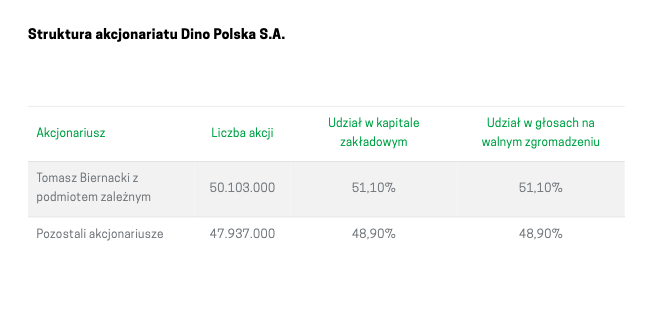

Każda akcja Dino Polska S.A. uprawnia do wykonywania jednego głosu na walnym zgromadzeniu.

Ponad 50% udziałow należy do założyciela spółki.

### 1.3 Wybrane dane finansowe

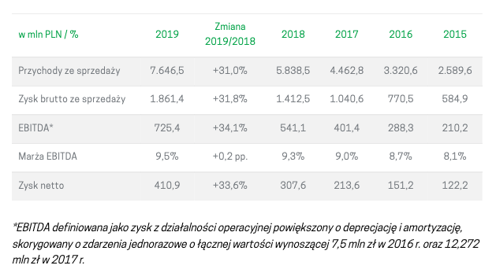

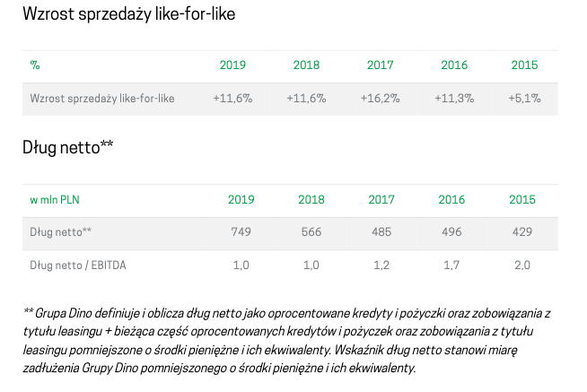

### 1.4 Notowania giełdowe spółki

Kurs odniesienia spółki Grupa Dino 8 maja wynosiła 169,90 zł.

Od debiutu w GPW zauważalny jest widoczny trend wznoszący wskazujący apetyt inwestorów na spółki najszybciej rozwijające się.

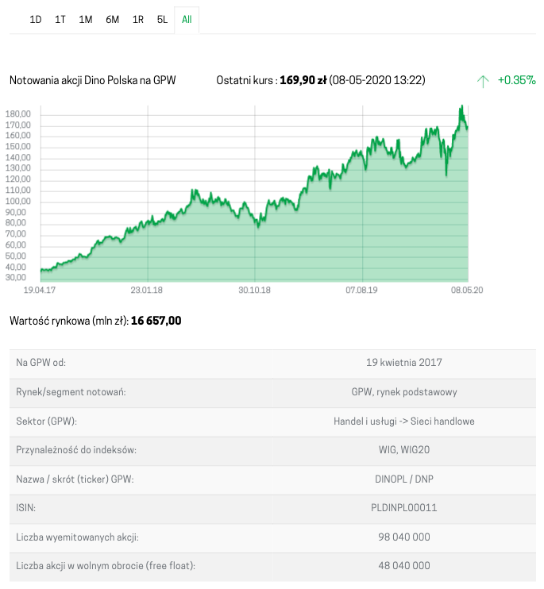

#### 1.4.1 Cena akcji w porównaniu z WIG

(na niebiesko: Dino, na żółto: WIG)

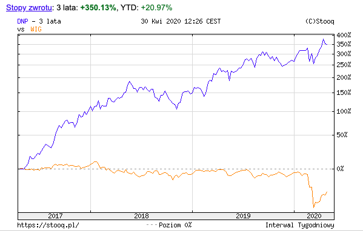

Na wykresie widzimy wyraźny wzrost cen akcji Dino Polska w porównaniu z WIG. Sytuacja związana z koronawirusem jedynie chwilowo wpłynęła na spadek wartości akcji, po czym, znów nastąpił wzrost.

Supermarkety nie należą do rodzaju spółek cyklicznych, a wieć koniunktura gospodarcza nie ma wiekszego wpływu na działalność.

## 2 Wstępna analiza bilansu

### 2.1 Analiza pionowa bilansu

| Aktywa | Stan na koniec roku (w.tys.zł.) 2017 | Stan na koniec roku (w.tys.zł.) 2018 | Stan na koniec roku (w.tys.zł.) 2019 | Struktura (w%) 2017 | Struktura (w%) 2018 | Struktura (w%) 2019 | Str. wewn. (w%) 2017 | Str. wewn. (w%) 2018 | Str. wewn. (w%) 2019 |
| --- | --- | --- | --- | --- | --- | --- | --- | --- | --- |
| A. Aktywa trwałe | 1547215 | 2031010 | 2660390 | 68.3 | 68.2 | 67.9 | 100 | 100 | 100 |
| I. Wartości niematerialne i prawne | 22486 | 22868 | 26024 | 1 | 0.8 | 0.7 | 1.5 | 1.1 | 1 |
| II. Rzeczowe aktywa trwałe | 773843 | 1256963 | 1848345 | 34.1 | 42.2 | 47.2 | 50 | 61.9 | 69.5 |
| III. Należności długoterminowe | - | - | - | - | - | - | - | - | - |
| IV. Inwestycje długoterminowe | 728943 | 727435 | 755835 | 32.2 | 24.4 | 19.3 | 47.1 | 35.8 | 28.4 |
| V. Długoterminowe rozliczenia międzyokresowe | 21943 | 23744 | 30186 | 1 | 0.8 | 0.8 | 1.4 | 1.2 | 1.1 |
| B. Aktywa obrotowe | 719008 | 948885 | 1257896 | 31.7 | 31.8 | 32.1 | 100 | 100 | 100 |
| I. Zapasy | 358573 | 428621 | 601195 | 15.8 | 14.4 | 15.3 | 49.9 | 45.2 | 47.8 |
| II. Należności krótkoterminowe | 70307 | 96203 | 100447 | 3.1 | 3.2 | 2.6 | 9.8 | 10.1 | 8 |
| III. Inwestycje krótkoterminowe | 257422 | 421645 | 554276 | 11.4 | 14.1 | 14.1 | 35.8 | 44.4 | 44.1 |
| IV. Krótkoterminowe rozliczenia międzyokresowe | 32706 | 2416 | 1978 | 1.4 | 0.1 | 0.1 | 4.5 | 0.3 | 0.2 |
| Aktywa razem | 2266223 | 2979895 | 3918286 | 100 | 100 | 100 | - | - | - |

| Pasywa | na koniec roku (w. tys. zł.) 2017 | na koniec roku (w. tys. zł.) 2018 | na koniec roku (w. tys. zł.) 2019 | Struktura (w%) 2017 | Struktura (w%) 2018 | Struktura (w%) 2019 | Str. wewn. (w%) 2017 | Str. wewn. (w%) 2018 | Str. wewn. (w%) 2019 |
| --- | --- | --- | --- | --- | --- | --- | --- | --- | --- |
| A. Kapitał (fundusz) własny | 758624 | 929970 | 1248171 | 33.5 | 31.2 | 31.9 | 100 | 100 | 100 |
| I. Kapitał (fundusz) podstawowy | 9804 | 9804 | 9804 | 0.4 | 0.3 | 0.3 | 1.3 | 1.1 | 0.8 |
| II. Kapitał (fundusz) zapasowy | 621345 | 681260 | 889818 | 27.4 | 22.9 | 22.7 | 81.9 | 73.3 | 71.3 |
| III. Kapitał (fundusz) z aktualizacji wyceny | - | - | - | - | - | - | - | - | - |
| IV. Pozostałe kapitały (fundusze) rezerwowe | - | - | - | - | - | - | - | - | - |
| V. Zysk/ (strata) z lat ubiegłych | -18816 | - | - | -0.8 | - | - | -2.5 | - | - |
| VI. Zysk/ (strata) netto | 139158 | 208558 | 318201 | 6.1 | 7 | 8.1 | 18.3 | 22.4 | 25.5 |
| VII. Pozostałe składniki kapitałów własnych | 7133 | 31783 | 30348 | 0.3 | 1.1 | 0.8 | 0.9 | 3.4 | 2.4 |
| VIII. Odpisy z zysku netto w ciągu roku obrotowego (wielkość ujemna) | - | -1435 | - | - | 0 | - | - | -0.2 | - |
| B. Zobowiązania i rezerwy na zobowiązania | 1507599 | 2049925 | 2670115 | 66.5 | 68.8 | 68.1 | 100 | 100 | 100 |
| I. Rezerwy na zobowiązania | 20537 | 29670 | 39639 | 0.9 | 1 | 1 | 1.4 | 1.4 | 1.5 |
| II. Zobowiązania długoterminowe | 492041 | 600881 | 681932 | 21.7 | 20.2 | 17.4 | 32.6 | 29.3 | 25.5 |
| III. Zobowiązania krótkoterminowe | 975747 | 1397539 | 1922179 | 43.1 | 46.9 | 49.1 | 64.7 | 68.2 | 72 |
| IV. Rozliczenia międzyokresowe | 19274 | 21835 | 26365 | 0.9 | 0.7 | 0.7 | 1.3 | 1.1 | 1 |
| Pasywa razem | 2266223 | 2979895 | 3918286 | 100 | 100 | 100 | - | - | - |

### 2.2 Analiza pozioma bilansu

```r
col_names <- c("Aktywa", '2017', '2018', '2019', '2018', '2019',
               '2017/18', '2018/19', '2017/18', '2018/19')
aktywa %>%
  select_at(vars(1, 4:6, 9:10, 13:14, 17:18)) %>%
  filter_at(vars(1), ~ str_detect(.x, '^[VIAB]')) %>%
  mutate(`Wyszczegónienie` =
           cell_spec(`Wyszczegónienie`,
                     italic = ifelse(row_number() %in% c(2:6, 8:11), T, F))) %>%
  kable(escape = F, col.names = col_names) %>%
  kable_styling(c("striped", "bordered")) %>%
  add_header_above(c(" " = 1, "Ceny bieżące" = 3, "Ceny skorygowane" = 2,
                     "Ceny bieżące" = 2, "Ceny skorygowane" = 2)) %>%
  add_header_above(c(" " = 1, "Stan na koniec roku (w. tys. zł.)" = 5,
                     "Dynamika (w%)" = 4)) %>%
  row_spec(c(1, 7, 12), bold = T) %>%
  column_spec(5:6, background = "#F0FBEF") %>%
  column_spec(7:8, background = "#F0FCD9") %>%
  column_spec(9:10, background = "#E7FDCF")
```

| Aktywa | Stan na koniec roku (w. tys. zł.) Ceny bieżące 2017 | Stan na koniec roku (w. tys. zł.) Ceny bieżące 2018 | Stan na koniec roku (w. tys. zł.) Ceny bieżące 2019 | Stan na koniec roku (w. tys. zł.) Ceny skorygowane 2018 | Stan na koniec roku (w. tys. zł.) Ceny skorygowane 2019 | Dynamika (w%) Ceny bieżące 2017/18 | Dynamika (w%) Ceny bieżące 2018/19 | Dynamika (w%) Ceny skorygowane 2017/18 | Dynamika (w%) Ceny skorygowane 2018/19 |
| --- | --- | --- | --- | --- | --- | --- | --- | --- | --- |
| A. Aktywa trwałe | 1547215 | 2031010 | 2660390 | 1995098 | 2608225 | 31.3 | 31 | 28.9 | 28.4 |
| I. Wartości niematerialne i prawne | 22486 | 22868 | 26024 | 22464 | 25514 | 1.7 | 13.8 | -0.1 | 11.6 |
| II. Rzeczowe aktywa trwałe | 773843 | 1256963 | 1848345 | 1234738 | 1812103 | 62.4 | 47 | 59.6 | 44.2 |
| III. Należności długoterminowe | - | - | - | - | - | - | - | - | - |
| IV. Inwestycje długoterminowe | 728943 | 727435 | 755835 | 714573 | 741015 | -0.2 | 3.9 | -2 | 1.9 |
| V. Długoterminowe rozliczenia międzyokresowe | 21943 | 23744 | 30186 | 23324 | 29594 | 8.2 | 27.1 | 6.3 | 24.6 |
| B. Aktywa obrotowe | 719008 | 948885 | 1257896 | 932107 | 1233231 | 32 | 32.6 | 29.6 | 30 |
| I. Zapasy | 358573 | 428621 | 601195 | 421042 | 589407 | 19.5 | 40.3 | 17.4 | 37.5 |
| II. Należności krótkoterminowe | 70307 | 96203 | 100447 | 94502 | 98477 | 36.8 | 4.4 | 34.4 | 2.4 |
| III. Inwestycje krótkoterminowe | 257422 | 421645 | 554276 | 414190 | 543408 | 63.8 | 31.5 | 60.9 | 28.9 |
| IV. Krótkoterminowe rozliczenia międzyokresowe | 32706 | 2416 | 1978 | 2373 | 1939 | -92.6 | -18.1 | -92.7 | -19.7 |
| Aktywa razem | 2266223 | 2979895 | 3918286 | 2927205 | 3841457 | 31.5 | 31.5 | 29.2 | 28.9 |

```r
col_names <- c("Pasywa", '2017', '2018', '2019', '2018', '2019',
               '2017/18', '2018/19', '2017/18', '2018/19')
pasywa %>%
  select_at(vars(1, 4:6, 9:10, 13:14, 17:18)) %>%
  filter_at(vars(1), ~ str_detect(.x, '^[VIABP]')) %>%
  mutate(`Wyszczegónienie` =
           cell_spec(`Wyszczegónienie`,
                     italic = ifelse(row_number() %in% c(2:9, 11:14), T, F))) %>%
  kable(escape = F, col.names = col_names) %>%
  kable_styling(c("striped", "bordered")) %>%
  add_header_above(c(" " = 1, "Ceny bieżące" = 3, "Ceny skorygowane" = 2,
                     "Ceny bieżące" = 2, "Ceny skorygowane" = 2)) %>%
  add_header_above(c(" " = 1, "Stan na koniec roku (w. tys. zł.)" = 5,
                     "Dynamika (w%)" = 4)) %>%
  row_spec(c(1, 10, 15), bold = T) %>%
  column_spec(5:6, background = "#F0FBEF") %>%
  column_spec(7:8, background = "#F0FCD9") %>%
  column_spec(9:10, background = "#E7FDCF")
```

| Pasywa | Stan na koniec roku (w. tys. zł.) Ceny bieżące 2017 | Stan na koniec roku (w. tys. zł.) Ceny bieżące 2018 | Stan na koniec roku (w. tys. zł.) Ceny bieżące 2019 | Stan na koniec roku (w. tys. zł.) Ceny skorygowane 2018 | Stan na koniec roku (w. tys. zł.) Ceny skorygowane 2019 | Dynamika (w%) Ceny bieżące 2017/18 | Dynamika (w%) Ceny bieżące 2018/19 | Dynamika (w%) Ceny skorygowane 2017/18 | Dynamika (w%) Ceny skorygowane 2018/19 |
| --- | --- | --- | --- | --- | --- | --- | --- | --- | --- |
| A. Kapitał (fundusz) własny | 758624 | 929970 | 1248171 | 913527 | 1223697 | 22.6 | 34.2 | 20.4 | 31.6 |
| I. Kapitał (fundusz) podstawowy | 9804 | 9804 | 9804 | 9631 | 9612 | 0 | 0 | -1.8 | -2 |
| II. Kapitał (fundusz) zapasowy | 621345 | 681260 | 889818 | 669214 | 872371 | 9.6 | 30.6 | 7.7 | 28.1 |
| III. Kapitał (fundusz) z aktualizacji wyceny | - | - | - | - | - | - | - | - | - |
| IV. Pozostałe kapitały (fundusze) rezerwowe | - | - | - | - | - | - | - | - | - |
| V. Zysk/ (strata) z lat ubiegłych | -18816 | - | - | - | - | - | - | - | - |
| VI. Zysk/ (strata) netto | 139158 | 208558 | 318201 | 204870 | 311962 | 49.9 | 52.6 | 47.2 | 49.6 |
| VII. Pozostałe składniki kapitałów własnych | 7133 | 31783 | 30348 | 31221 | 29753 | 345.6 | -4.5 | 337.7 | -6.4 |
| VIII. Odpisy z zysku netto w ciągu roku obrotowego (wielkość ujemna) | - | -1435 | - | -1410 | - | - | - | - | - |
| B. Zobowiązania i rezerwy na zobowiązania | 1507599 | 2049925 | 2670115 | 2013679 | 2617760 | 36 | 30.3 | 33.6 | 27.7 |
| I. Rezerwy na zobowiązania | 20537 | 29670 | 39639 | 29145 | 38862 | 44.5 | 33.6 | 41.9 | 31 |
| II. Zobowiązania długoterminowe | 492041 | 600881 | 681932 | 590256 | 668561 | 22.1 | 13.5 | 20 | 11.3 |
| III. Zobowiązania krótkoterminowe | 975747 | 1397539 | 1922179 | 1372828 | 1884489 | 43.2 | 37.5 | 40.7 | 34.8 |
| IV. Rozliczenia międzyokresowe | 19274 | 21835 | 26365 | 21449 | 25848 | 13.3 | 20.7 | 11.3 | 18.4 |
| Pasywa razem | 2266223 | 2979895 | 3918286 | 2927205 | 3841457 | 31.5 | 31.5 | 29.2 | 28.9 |

```r
NA
```

## Załącznik

### Bilans

```r
#bold <-
bold_r <- function(tabl) {
  return(na.omit(tabl %>%
                   select(1) %>%
                   mutate_at(vars(1), ~ ifelse(str_detect(.x, '^[ABP]'), row_number(), NA)) %>%
                   unlist(., use.names=FALSE)))
}

italic_r <- function(tabl) {
  return(na.omit(aktywa %>%
                   select(1) %>%
                   mutate_at(vars(1), ~ ifelse(str_detect(.x, '^[VI]'), row_number(), NA)) %>%
                   unlist(., use.names=FALSE)))
}

aktywa %>%
  select_at(vars(1:6)) %>%
  kable(booktabs = T, escape = F) %>%
  kable_styling(c("striped", "bordered")) %>%
  row_spec(bold_r(aktywa), bold = T) %>%
  row_spec(italic_r(aktywa), italic = T) %>%
  add_indent(setdiff(1:count(aktywa)[[1]], c(bold_r(aktywa), italic_r(aktywa))))
```

| Wyszczegónienie | 2015 | 2016 | 2017 | 2018 | 2019 |
| --- | --- | --- | --- | --- | --- |
| A. Aktywa trwałe | 848301 | 1237533 | 1547215 | 2031010 | 2660390 |
| I. Wartości niematerialne i prawne | 9832 | 10439 | 22486 | 22868 | 26024 |
| 3 Inne wartości niematerialne i prawne | 9832 | 10439 | 22486 | 22868 | 26024 |
| II. Rzeczowe aktywa trwałe | 235488 | 456604 | 773843 | 1256963 | 1848345 |
| 1 Środki trwałe | 213782 | 422970 | 722390 | 1184076 | 1763005 |
| a) grunty (w tym prawo użytkowania wieczystego gruntu) | 21284 | 68264 | 126267 | 215673 | 335637 |
| b) budynki, lokale, prawa do lokali i obiekty inżynierii lądowej i wodnej | 24206 | 134048 | 323573 | 608108 | 971051 |
| c) urządzenia techniczne i maszyny | 88415 | 114065 | 145299 | 204103 | 256928 |
| d) środki transportu | 9469 | 17343 | 29104 | 39731 | 62526 |
| e) inne środki trwałe | 70408 | 89250 | 98147 | 116461 | 136863 |
| 2 Środki trwałe w budowie | 21706 | 33634 | 51453 | 72887 | 85340 |
| III. Należności długoterminowe | - | - | - | - | - |
| IV. Inwestycje długoterminowe | 522397 | 727151 | 728943 | 727435 | 755835 |
| 3 Długoterminowe aktywa finansowe | 522397 | 727151 | 728943 | 727435 | 755835 |
| a) w jednostkach powiązanych | 522397 | 727151 | 728943 | 727435 | 755835 |
| - udziały lub akcje | 522397 | 727151 | 727285 | 727435 | 755835 |
| - inne papiery wartościowe | - | - | 1658 | - | - |
| V. Długoterminowe rozliczenia międzyokresowe | 80584 | 43339 | 21943 | 23744 | 30186 |
| 1 Aktywa z tytułu odroczonego podatku dochodowego | 7706 | 12105 | 21943 | 23744 | 30186 |
| 2 Inne rozliczenia międzyokresowe | 72878 | 31234 | - | - | - |
| B. Aktywa obrotowe | 336913 | 484944 | 719008 | 948885 | 1257896 |
| I. Zapasy | 209431 | 270798 | 358573 | 428621 | 601195 |
| 4 Towary | 209431 | 270798 | 358573 | 428621 | 601195 |
| II. Należności krótkoterminowe | 28331 | 49827 | 70307 | 96203 | 100447 |
| 1 Należności od jednostek powiązanych | 1370 | 908 | 7985 | 10825 | 1021 |
| a) z tytułu dostaw i usług, o okresie spłaty: | 504 | 510 | 7462 | 8620 | 991 |
| - do 12 miesięcy | 504 | 510 | 7462 | 8620 | 991 |
| b) inne | 866 | 398 | 523 | 2205 | 30 |
| 2 Należności od pozostałych jednostek, w których jednostka posiada zaangażowanie w kapitale | - | - | - | - | - |
| 3 Należności od pozostałych jednostek | 26961 | 48919 | 62322 | 85378 | 99426 |
| a) -z tytułu dostaw i usług, o okresie spłaty: | 12644 | 25275 | 30662 | 13101 | 44591 |
| -- do 12 miesięcy | 12644 | 25275 | 30662 | 13101 | 44591 |
| b) z tytułu podatków, dotacji, ceł, ubezpieczeń społecznych i zdrowotnych oraz innych tytułów publicznoprawnych | 8229 | 17607 | 26566 | 51470 | 25683 |
| c) inne | 6088 | 6037 | 5094 | 20807 | 29152 |
| III. Inwestycje krótkoterminowe | 55158 | 121914 | 257422 | 421645 | 554276 |
| 1 Krótkoterminowe aktywa finansowe | 55158 | 121914 | 257422 | 421645 | 554276 |
| a) -w jednostkach powiązanych | 29301 | 67682 | 71444 | 162261 | 176539 |
| -- inne papiery wartościowe | - | 22179 | 24121 | 27570 | - |
| - udzielone pożyczki | 29301 | 45503 | 47323 | 134691 | 176539 |
| b) w pozostałych jednostkach | - | - | - | - | - |
| c) środki pieniężne i inne aktywa pieniężne | 25857 | 54232 | 185978 | 259384 | 377737 |
| - środki pieniężne w kasie i na rachunkach | 20266 | 35743 | 67070 | 79726 | 79330 |
| - inne środki pieniężne | 5591 | 18489 | 118908 | 179658 | 298407 |
| IV. Krótkoterminowe rozliczenia międzyokresowe | 43993 | 42405 | 32706 | 2416 | 1978 |
| C. Należne wpłaty na kapitał (fundusz) podstawowy | - | - | - | - | - |
| D. Udziały (akcje) własne | - | - | - | - | - |
| Aktywa razem | 1185214 | 1722477 | 2266223 | 2979895 | 3918286 |

```r
  #add_indent(c(c(2,3,5,6))) %>%
```